# WCST, PRL, and Task Switching for Discriminating AN Patients and Healthy Controls

AUC analysis

Author

Corrado Caudek

Published

July 27, 2024

## 1 Project Overview

This project aims to compare the effectiveness of different cognitive tasks (Wisconsin Card Sorting Test, Probabilistic Reversal Learning, and Task Switching) in discriminating between anorexia nervosa (AN) patients and healthy controls.

## 2 Setup

```r
# Load necessary libraries
library(tidyverse)
library(cmdstanr)
library(bayesplot)
bayesplot_theme_set(theme_default(base_size = 8, base_family = "sans"))
library(pROC)
library(missRanger)

# Set project root
proj_root <- here::here()
```

## 3 Data Preparation

### 3.1 1. WCST Steinke Parameters

The predictors are the individual coefficients of Steinke’s model applied to the WCST. The model’s coefficients for each participant have been obtained with a hierarchical Bayesian model.

```r
data1 <- rio::import(
    file.path(
      proj_root,
      "src", "stan_auc", "models_params", "wcst_steinke_rev_params.csv"
    )
  ) |>
    # dplyr::select(-index) |>
    mutate(across(-is_patient, ~ scale(.) |> as.numeric()))
```

### 3.2 2. PRL hDDMrl Parameters

The predictors are the individual coefficients of hDDMrl model applied to the PRL task. The model’s coefficients for each participant have been obtained with the hDDMrl Python module.

```r
data2 <- rio::import(
    file.path(proj_root, "src", "stan_auc", "models_params", "prl_params.csv")
) |>
    dplyr::select(-index) |>
    mutate(across(-is_patient, ~ scale(.) |> as.numeric()))
```

### 3.3 3. WCST Behavioral Indices

The beahavioral indices have been obtained from the empirical data of the two groups.

```r
data3 <- rio::import(
    file.path(proj_root, "src", "stan_auc", "models_params", "wcst_behav_indices.csv")
) |>
    mutate(is_patient = ifelse(group == "an", 1, 0)) |>
    dplyr::select(-c(subj_name, group))

# Impute missing values
data3 <- missRanger(data3, pmm.k = 5, num.trees = 100)

# Standardize
data3 <- data3 |>
    mutate(across(-is_patient, ~ scale(.) |> as.numeric()))
```

## 4 Task Switching DDM Parameters

```r
data4 <- rio::import(
    file.path(proj_root, "src", "stan_auc", "models_params",
              "task_switching_params.csv")
) |>
    dplyr::select(-subj_idx)

data4 <- data4 %>%
    dplyr::select(-is_patient, everything(), is_patient)

# Standardize
data4 <- data4 |>
    mutate(across(-is_patient, ~ scale(.) |> as.numeric()))
```

## 5 Task Switching Behavioral Indices

```r
data5 <- rio::import(
    file.path(proj_root, "src", "stan_auc", "models_params",
              "task_switching_behav_indices.csv")
) |>
    dplyr::rename(
        "cost_resp_rep" = "repetition",
        "cost_resp_switch" = "switch"
    )

# Standardize
data5 <- data5 |>
    mutate(across(-is_patient, ~ scale(.) |> as.numeric()))
```

## 6 PRL Behavioral Indices

```r
data6 <- rio::import(
    file.path(
        proj_root, "src", "stan_auc", "models_params",
        "prl_behav_indices.csv"
    )
)

# Standardize
data6 <- data6 |>
    mutate(across(-is_patient, ~ scale(.) |> as.numeric()))
```

## 7 Stan Model Preparation

Generate an R list as required for the Stan model.

```r
stan_data <- list(
    N1 = nrow(data1),
    N2 = nrow(data2),
    N3 = nrow(data3),
    N4 = nrow(data4),
    N5 = nrow(data5),
    N6 = nrow(data6),
    #
    K1 = 8,
    K2 = 5,
    K3 = 3,
    K4 = 6,
    K5 = 2,
    K6 = 3,
    #
    X1 = as.matrix(data1[, c(
        "MB_Arew", "MB_Apun", "MB_gamma", "MF_Arew",
        "MF_Apun", "MF_gamma", "temp", "w"
    )]),
    X2 = as.matrix(data2[, c("a", "alpha", "pos_alpha", "t", "v")]),
    X3 = as.matrix(data3[, c(
        "prop_pers_err", "prop_non_pers_err", "prop_pers_resp"
    )]),
    X4 = as.matrix(data4[, c("a_0", "a_1", "v_0", "v_1", "t_0", "t_1")]),
    X5 = as.matrix(data5[, c("cost_resp_rep", "cost_resp_switch")]),
    X6 = as.matrix(data6[, c("win_stay", "lose_shift", "e_pers")]),
    #
    y1 = data1$is_patient,
    y2 = data2$is_patient,
    y3 = data3$is_patient,
    y4 = data4$is_patient,
    y5 = data5$is_patient,
    y6 = data6$is_patient
)
```

## 8 Model Fitting

```r
model_path <- file.path(
    proj_root, "src", "stan_auc",
    "auc_3model_comparison.stan"
)
model <- cmdstan_model(model_path)

fit <- model$sample(
    data = stan_data,
    seed = 123,
    chains = 4,
    parallel_chains = 4,
    iter_warmup = 20000,
    iter_sampling = 20000
)
```

## 9 Results Analysis

```r
posterior <- fit$draws(
    c(
        "auc1", "auc2", "auc3", "auc4", "auc5", "auc6",
        "auc_diff_params_prl_wcst",
        "auc_diff_params_prl_ts",
        "auc_diff_params_ts_wcst",
        #
        "auc_diff_behav_indices_prl_wcst",
        "auc_diff_behav_indices_prl_ts",
        "auc_diff_behav_indices_ts_wcst",
        #
        "auc_diff_params_indices_prl",
        "auc_diff_params_indices_wcst",
        "auc_diff_params_indices_ts"
    ),
    format = "df"
)

summary <- posterior |>
    pivot_longer(everything(), names_to = "parameter", values_to = "value") |>
    group_by(parameter) |>
    summarize(
        mean = mean(value),
        median = median(value),
        sd = sd(value),
        q2.5 = quantile(value, 0.025),
        q97.5 = quantile(value, 0.975)
    )

print(summary)
```

```
# A tibble: 18 × 6
   parameter                             mean    median      sd     q2.5   q97.5
   <chr>                                <dbl>     <dbl>   <dbl>    <dbl>   <dbl>
 1 .chain                              2.5      2.5 e+0 1.12e+0  1   e+0 4   e+0
 2 .draw                           40000.       4.00e+4 2.31e+4  2.00e+3 7.80e+4
 3 .iteration                      10000.       1.00e+4 5.77e+3  5.01e+2 1.95e+4
 4 auc1                                0.725    7.29e-1 2.17e-2  6.72e-1 7.56e-1
 5 auc2                                0.805    8.08e-1 1.51e-2  7.70e-1 8.27e-1
 6 auc3                                0.637    6.47e-1 5.57e-2  5.11e-1 7.11e-1
 7 auc4                                0.752    7.55e-1 1.59e-2  7.13e-1 7.74e-1
 8 auc5                                0.770    7.73e-1 9.32e-3  7.44e-1 7.78e-1
 9 auc6                                0.759    7.63e-1 1.22e-2  7.28e-1 7.71e-1
10 auc_diff_behav_indices_prl_ts      -0.0110  -9.28e-3 1.54e-2 -4.45e-2 1.83e-2
11 auc_diff_behav_indices_prl_wcst     0.122    1.12e-1 5.70e-2  4.13e-2 2.49e-1
12 auc_diff_behav_indices_ts_wcst      0.133    1.23e-1 5.65e-2  5.66e-2 2.60e-1
13 auc_diff_params_indices_prl         0.0461   4.65e-2 1.95e-2  6.53e-3 8.48e-2
14 auc_diff_params_indices_ts         -0.0179  -1.62e-2 1.84e-2 -5.93e-2 1.47e-2
15 auc_diff_params_indices_wcst        0.0880   7.94e-2 5.98e-2 -6.36e-3 2.18e-1
16 auc_diff_params_prl_ts              0.0530   5.27e-2 2.19e-2  9.90e-3 9.83e-2
17 auc_diff_params_prl_wcst            0.0798   7.81e-2 2.64e-2  3.21e-2 1.38e-1
18 auc_diff_params_ts_wcst             0.0269   2.53e-2 2.68e-2 -2.35e-2 8.49e-2
```

## 10 Visualization

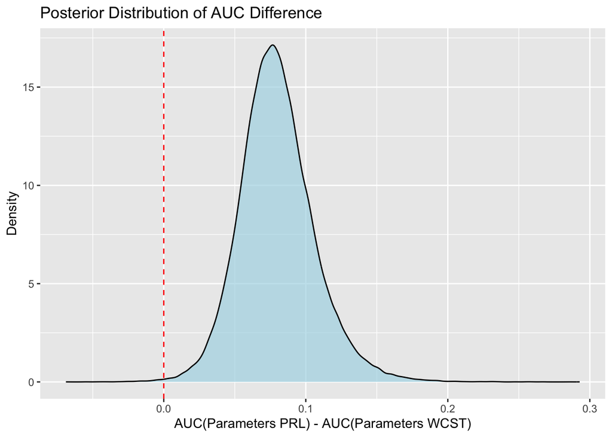

```r
ggplot(posterior, aes(x = auc_diff_params_prl_wcst)) +
    geom_density(fill = "lightblue", alpha = 0.7) +
    geom_vline(xintercept = 0, linetype = "dashed", color = "red") +
    labs(
        title = "Posterior Distribution of AUC Difference",
        x = "AUC(Parameters PRL) - AUC(Parameters WCST)",
        y = "Density"
    )
```

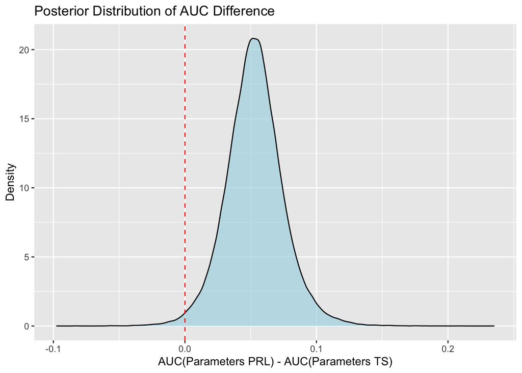

```r
ggplot(posterior, aes(x = auc_diff_params_prl_ts)) +
    geom_density(fill = "lightblue", alpha = 0.7) +
    geom_vline(xintercept = 0, linetype = "dashed", color = "red") +
    labs(
        title = "Posterior Distribution of AUC Difference",
        x = "AUC(Parameters PRL) - AUC(Parameters TS)",
        y = "Density"
    )
```

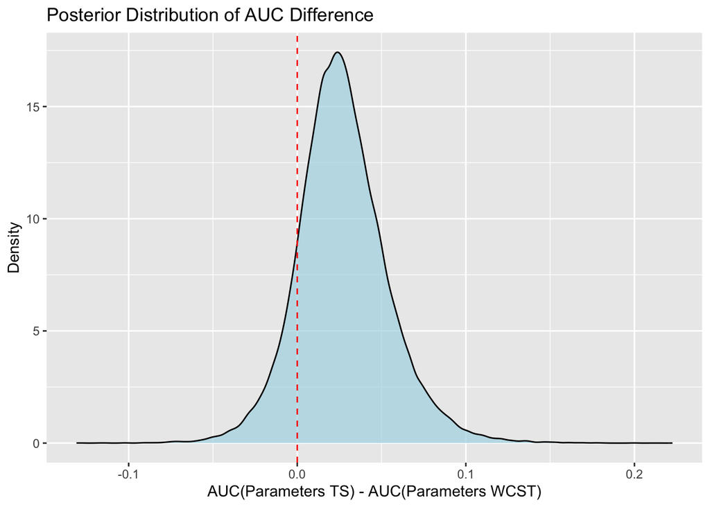

```r
ggplot(posterior, aes(x = auc_diff_params_ts_wcst)) +
    geom_density(fill = "lightblue", alpha = 0.7) +
    geom_vline(xintercept = 0, linetype = "dashed", color = "red") +
    labs(
        title = "Posterior Distribution of AUC Difference",
        x = "AUC(Parameters TS) - AUC(Parameters WCST)",
        y = "Density"
    )
```

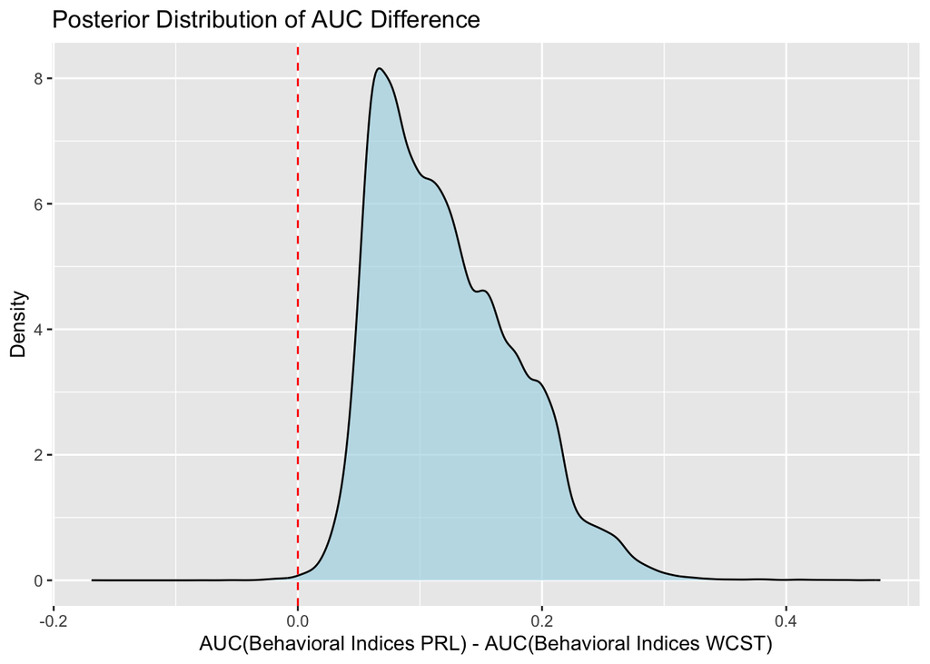

```r
# --
ggplot(posterior, aes(x = auc_diff_behav_indices_prl_wcst)) +
    geom_density(fill = "lightblue", alpha = 0.7) +
    geom_vline(xintercept = 0, linetype = "dashed", color = "red") +
    labs(
        title = "Posterior Distribution of AUC Difference",
        x = "AUC(Behavioral Indices PRL) - AUC(Behavioral Indices WCST)",
        y = "Density"
    )
```

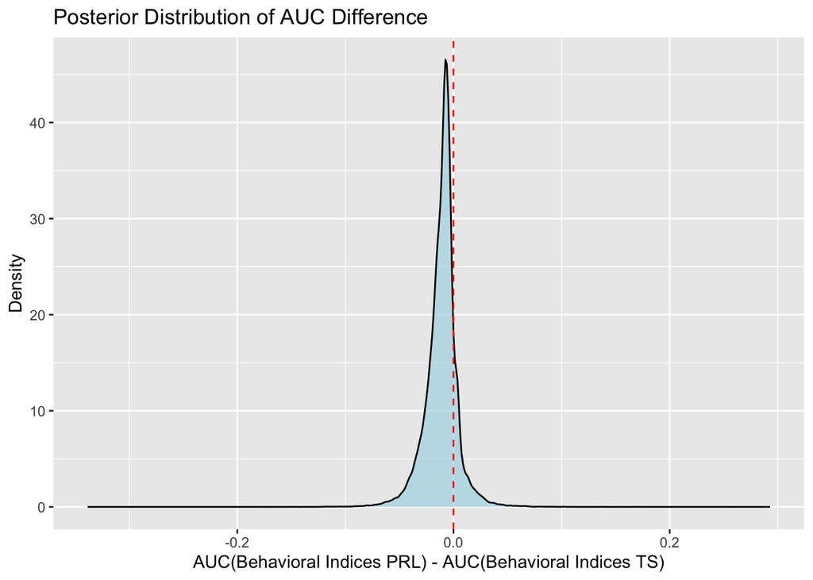

```r
ggplot(posterior, aes(x = auc_diff_behav_indices_prl_ts)) +
    geom_density(fill = "lightblue", alpha = 0.7) +
    geom_vline(xintercept = 0, linetype = "dashed", color = "red") +
    labs(
        title = "Posterior Distribution of AUC Difference",
        x = "AUC(Behavioral Indices PRL) - AUC(Behavioral Indices TS)",
        y = "Density"
    )
```

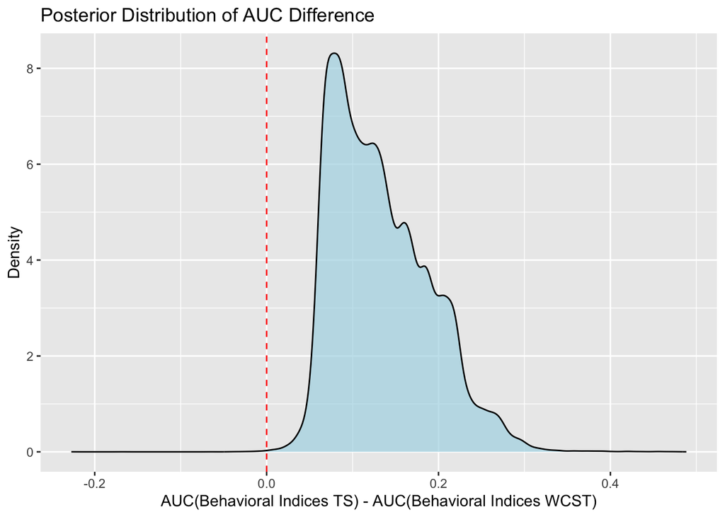

```r
ggplot(posterior, aes(x = auc_diff_behav_indices_ts_wcst)) +
    geom_density(fill = "lightblue", alpha = 0.7) +
    geom_vline(xintercept = 0, linetype = "dashed", color = "red") +
    labs(
        title = "Posterior Distribution of AUC Difference",
        x = "AUC(Behavioral Indices TS) - AUC(Behavioral Indices WCST)",
        y = "Density"
    )
```

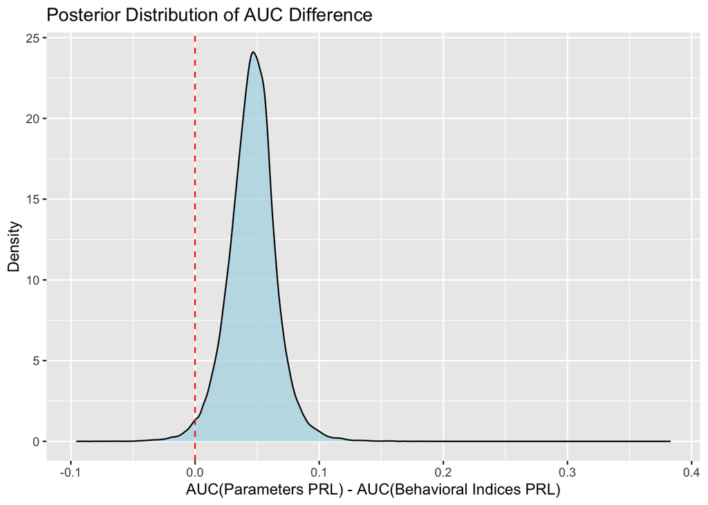

```r
# --
ggplot(posterior, aes(x = auc_diff_params_indices_prl)) +
    geom_density(fill = "lightblue", alpha = 0.7) +
    geom_vline(xintercept = 0, linetype = "dashed", color = "red") +
    labs(
        title = "Posterior Distribution of AUC Difference",
        x = "AUC(Parameters PRL) - AUC(Behavioral Indices PRL)",
        y = "Density"
    )
```

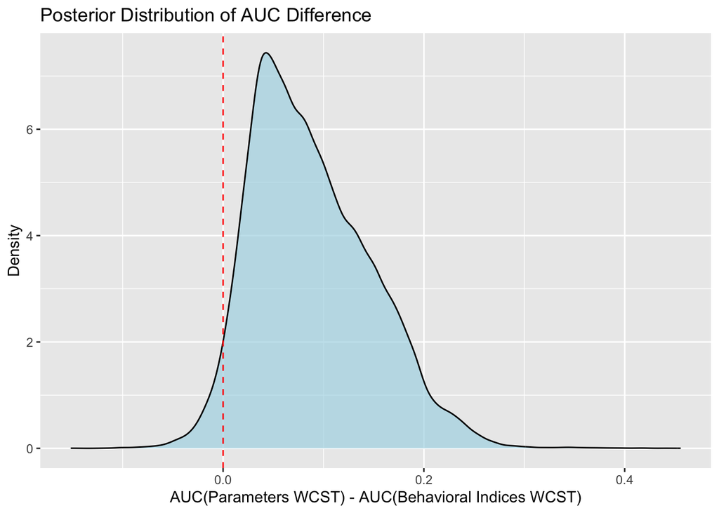

```r
ggplot(posterior, aes(x = auc_diff_params_indices_wcst)) +
    geom_density(fill = "lightblue", alpha = 0.7) +
    geom_vline(xintercept = 0, linetype = "dashed", color = "red") +
    labs(
        title = "Posterior Distribution of AUC Difference",
        x = "AUC(Parameters WCST) - AUC(Behavioral Indices WCST)",
        y = "Density"
    )
```

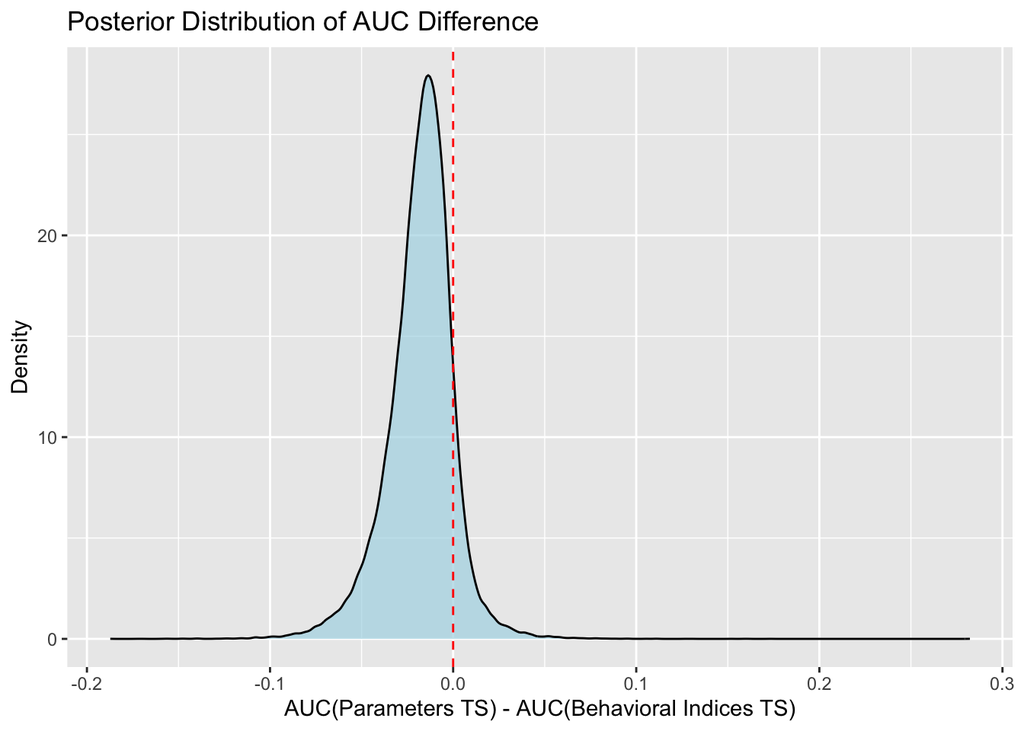

```r
ggplot(posterior, aes(x = auc_diff_params_indices_ts)) +
    geom_density(fill = "lightblue", alpha = 0.7) +
    geom_vline(xintercept = 0, linetype = "dashed", color = "red") +
    labs(
        title = "Posterior Distribution of AUC Difference",
        x = "AUC(Parameters TS) - AUC(Behavioral Indices TS)",
        y = "Density"
    )
```

## 11 Conclusion

```r
prob_auc_diff_params_prl_wcst_pos <-
    mean(posterior$auc_diff_params_prl_wcst > 0)

cat(
    "Probability that PRL params outperforms WCST params:",
    prob_auc_diff_params_prl_wcst_pos, "\n"
)
```

```
Probability that PRL params outperforms WCST params: 0.998175
```

```r
prob_auc_diff_params_prl_ts_pos <-
    mean(posterior$auc_diff_params_prl_ts > 0)

cat(
    "Probability that PRL params outperforms TS params:",
    prob_auc_diff_params_prl_ts_pos, "\n"
)
```

```
Probability that PRL params outperforms TS params: 0.989775
```

```r
prob_auc_diff_params_indices_ts_pos <-
    mean(posterior$auc_diff_params_indices_ts > 0)

cat(
    "Probability that TS params outperforms TS behav indices:",
    prob_auc_diff_params_indices_ts_pos, "\n"
)
```

```
Probability that TS params outperforms TS behav indices: 0.11375
```